# Park accessibility in Seoul: CCREM with corrected age coding

Dawon Oh

2026-10-05

# Overview

This document runs the cross-classified random-effects model (CCREM) for the Seoul park accessibility paper and makes all figures in R.

It includes two corrections to the earlier Python code.

1. **Age coding.** The 70+ group (`M_7000`, `W_7000`) is coded as age 75. The earlier code read `7000` as (70 + 0) / 2 = 35. In the figures, 65–69 now belongs to the 60–69 group.
2. **Model terms.** Female × Age and Female × Age² are included as main terms. A likelihood-ratio test compares the model with and without them.

Set the paths in the `params` block at the top of this file. With `data_source: "wide"`, the file in `wide_file` must already contain the park variables (the merged file with 6,850 origin–park rows). With `data_source: "long"`, the document reads `data_long_for_R.csv` from the Python notebook.

Packages needed: `lme4`, `lmerTest`, `ggplot2`. All other steps use base R.

# 0. Setup

```r
library(lme4)
library(lmerTest)
library(ggplot2)

# lme4 versions built for R >= 4.4 use the %||% helper, which is missing in
# R 4.3. Define it here so that VarCorr() and rePCA() print correctly.
if (!exists("%||%", mode = "function")) {
  `%||%` <- function(x, y) if (is.null(x)) y else x
}

out_dir <- params$out_dir
dir.create(out_dir, recursive = TRUE, showWarnings = FALSE)

THETA <- params$theta
AMENITIES <- c("green_ratio", "user_ratio", "facility_number",
               "parking_number", "transit_number", "park_area_ha")
```

# 1. Age lookup tables

```r
# Age midpoint used in the regression, by the 4-digit code in the column name
AGE_MID <- c("0009" = 4.5,
             "1014" = 12, "1519" = 17,
             "2024" = 22, "2529" = 27,
             "3034" = 32, "3539" = 37,
             "4044" = 42, "4549" = 47,
             "5054" = 52, "5559" = 57,
             "6064" = 62, "6569" = 67,
             "7000" = 75)            # open band 70+

# Ten-year group used in the figures
AGE_LABEL <- c("0009" = "0-9",
               "1014" = "10-19", "1519" = "10-19",
               "2024" = "20-29", "2529" = "20-29",
               "3034" = "30-39", "3539" = "30-39",
               "4044" = "40-49", "4549" = "40-49",
               "5054" = "50-59", "5559" = "50-59",
               "6064" = "60-69", "6569" = "60-69",
               "7000" = "70+")
LABEL_ORDER <- c("0-9", "10-19", "20-29", "30-39",
                 "40-49", "50-59", "60-69", "70+")

# Ages at which marginal effects are reported
ME_AGES <- c("0-9" = 5, "10-19" = 15, "20-29" = 25, "30-39" = 35,
             "40-49" = 45, "50-59" = 55, "60-69" = 65, "70+" = 75)
```

# 2. Build the long data

```r
if (params$data_source == "wide") {

  wide <- read.csv(params$wide_file, check.names = FALSE, fileEncoding = "UTF-8")
  group_cols <- grep("^[MW]_[0-9]{4}$", names(wide), value = TRUE)
  stopifnot(length(group_cols) == 28)

  # Park variables (same definitions as the paper, Table 1)
  wide$green_ratio <- wide$greenarea_area / wide$park_area * 100
  wide$user_ratio  <- (wide$openspaace_area + wide$road_area +
                       wide$walkingtrail_area + wide$shadecanopy_area) /
                      wide$park_area * 100
  wide$facility_number <- wide$gymtrack_number + wide$swimmingpool_number +
                          wide$sportsfacility_number + wide$playground_number +
                          wide$cafeteria_number + wide$kiosk_number
  wide$parking_number <- wide$parkingcapacity_number
  wide$transit_number <- wide$bus500 + wide$sub500
  wide$park_area_ha   <- wide$park_area / 10000

  cat("Parks:", length(unique(wide$ID)),
      "| Origin gu:", length(unique(wide$INFLOW_CD)),
      "| Origin-park pairs:", nrow(wide), "\n")

  # Wide -> long: one row per origin-park pair and sex-age group
  keep <- c("INFLOW_CD", "ID", "c_eq_min", AMENITIES)
  dl <- do.call(rbind, lapply(group_cols, function(g) {
    data.frame(wide[, keep], group = g, visitors = wide[[g]])
  }))
  cat("Rows before removing zero cells:", nrow(dl), "\n")
  dl <- dl[dl$visitors > 0, ]
  cat("Rows after removing zero cells: ", nrow(dl), "\n")

  # Sex and age from the column name, using the lookup tables
  code <- sub("^[MW]_", "", dl$group)
  stopifnot(all(code %in% names(AGE_MID)))
  dl$female    <- as.integer(substr(dl$group, 1, 1) == "W")
  dl$age       <- unname(AGE_MID[code])
  dl$age_label <- unname(AGE_LABEL[code])

  # Check: 70+ must be 75
  check <- unique(dl[, c("group", "female", "age", "age_label")])
  print(check[order(check$female, check$age), ], row.names = FALSE)
  stopifnot(all(check$age[grepl("7000$", check$group)] == 75))

  AGE_MEAN <- mean(dl$age)
  dl$age_c    <- dl$age - AGE_MEAN
  dl$age_c_sq <- dl$age_c^2
  dl$w        <- dl$visitors / mean(dl$visitors)   # weights rescaled to mean 1

} else {

  dl <- read.csv(params$long_file)
  # age_c was centered in Python; recover the raw age from the smallest value,
  # which belongs to the 0-9 band (midpoint 4.5)
  AGE_MEAN <- 4.5 - min(dl$age_c)
  dl$age <- round(dl$age_c + AGE_MEAN, 2)
  stopifnot(all(dl$age %in% AGE_MID))
  dl$age_label <- unname(AGE_LABEL[match(dl$age, AGE_MID)])
  dl$age_c_sq <- dl$age_c^2
}
```

```
## Parks: 274 | Origin gu: 25 | Origin-park pairs: 6850
## Rows before removing zero cells: 191800
## Rows after removing zero cells:  191750
##   group female  age age_label
##  M_0009      0  4.5       0-9
##  M_1014      0 12.0     10-19
##  M_1519      0 17.0     10-19
##  M_2024      0 22.0     20-29
##  M_2529      0 27.0     20-29
##  M_3034      0 32.0     30-39
##  M_3539      0 37.0     30-39
##  M_4044      0 42.0     40-49
##  M_4549      0 47.0     40-49
##  M_5054      0 52.0     50-59
##  M_5559      0 57.0     50-59
##  M_6064      0 62.0     60-69
##  M_6569      0 67.0     60-69
##  M_7000      0 75.0       70+
##  W_0009      1  4.5       0-9
##  W_1014      1 12.0     10-19
##  W_1519      1 17.0     10-19
##  W_2024      1 22.0     20-29
##  W_2529      1 27.0     20-29
##  W_3034      1 32.0     30-39
##  W_3539      1 37.0     30-39
##  W_4044      1 42.0     40-49
##  W_4549      1 47.0     40-49
##  W_5054      1 52.0     50-59
##  W_5559      1 57.0     50-59
##  W_6064      1 62.0     60-69
##  W_6569      1 67.0     60-69
##  W_7000      1 75.0       70+
```

```r
cat("Sample mean age used for centering:", round(AGE_MEAN, 3), "\n")
```

```
## Sample mean age used for centering: 39.544
```

```r
cat("Observations:", nrow(dl), "\n")
```

```
## Observations: 191750
```

# 3. Interaction terms

```r
dl$female_age  <- dl$female * dl$age_c
dl$female_age2 <- dl$female * dl$age_c_sq
for (a in AMENITIES) {
  dl[[paste0(a, "_F")]]   <- dl[[a]] * dl$female
  dl[[paste0(a, "_A")]]   <- dl[[a]] * dl$age_c
  dl[[paste0(a, "_A2")]]  <- dl[[a]] * dl$age_c_sq
  dl[[paste0(a, "_FA")]]  <- dl[[a]] * dl$female * dl$age_c
  dl[[paste0(a, "_FA2")]] <- dl[[a]] * dl$female * dl$age_c_sq
}

DEMO_TERMS <- c("female", "age_c", "age_c_sq", "female_age", "female_age2")
AMEN_TERMS <- c(AMENITIES,
                paste0(AMENITIES, "_F"),  paste0(AMENITIES, "_A"),
                paste0(AMENITIES, "_A2"), paste0(AMENITIES, "_FA"),
                paste0(AMENITIES, "_FA2"))
FIXED_TERMS <- c(DEMO_TERMS, AMEN_TERMS)

dl$ID        <- factor(dl$ID)
dl$INFLOW_CD <- factor(dl$INFLOW_CD)

f_full <- as.formula(paste("c_eq_min ~", paste(FIXED_TERMS, collapse = " + "),
                           "+ (1|ID) + (1|INFLOW_CD)"))
f_noFA <- as.formula(paste("c_eq_min ~",
                           paste(setdiff(FIXED_TERMS, c("female_age", "female_age2")),
                                 collapse = " + "),
                           "+ (1|ID) + (1|INFLOW_CD)"))
cat("Fixed-effect terms:", length(FIXED_TERMS), "\n")
```

```
## Fixed-effect terms: 41
```

# 4. Variance inflation factors

```r
# VIF_j = 1 / (1 - R2_j), where R2_j comes from regressing term j on the others
vif_manual <- function(X) {
  X <- as.data.frame(X)
  sapply(names(X), function(v) {
    r2 <- summary(lm(X[[v]] ~ ., data = X[setdiff(names(X), v)]))$r.squared
    1 / (1 - r2)
  })
}

vif_main <- vif_manual(dl[, c("female", "age_c", "age_c_sq", AMENITIES)])
vif_full <- vif_manual(dl[, FIXED_TERMS])

vif_tab <- data.frame(term = names(vif_full), VIF_full = round(vif_full, 2))
vif_tab$VIF_main_design <- round(vif_main[vif_tab$term], 2)
vif_tab <- vif_tab[order(-vif_tab$VIF_full), ]
write.csv(vif_tab, file.path(out_dir, "vif.csv"), row.names = FALSE)

cat("Amenity VIFs, main-effects design:\n"); print(round(vif_main[AMENITIES], 2))
```

```
## Amenity VIFs, main-effects design:
```

```
##     green_ratio      user_ratio facility_number  parking_number  transit_number
##            1.07            1.06            1.06            1.09            1.81
##    park_area_ha
##            1.78
```

```r
cat("\nTen highest VIFs, full design:\n");   print(head(vif_tab[, 1:2], 10), row.names = FALSE)
```

```
##
## Ten highest VIFs, full design:
```

```
##                term VIF_full
##         female_age2    34.66
##     green_ratio_FA2    29.79
##              female    23.52
##            age_c_sq    22.30
##          female_age    22.30
##               age_c    22.29
##       green_ratio_F    21.66
##      green_ratio_A2    20.77
##  transit_number_FA2    19.87
##       green_ratio_A    18.39
```

# 5. Fit the CCREM

This chunk can take several minutes.

```r
ctrl <- lmerControl(optimizer = "bobyqa", optCtrl = list(maxfun = 2e5))
fit <- lmer(f_full, data = dl, weights = w, REML = TRUE, control = ctrl)

cat("isSingular:", isSingular(fit), "\n\n")
```

```
## isSingular: FALSE
```

```r
print(VarCorr(fit))
```

```
##  Groups    Name        Std.Dev.
##  ID        (Intercept) 17.8173
##  INFLOW_CD (Intercept)  7.6447
##  Residual              11.1117
```

```r
cat("\n")
```

```r
print(summary(rePCA(fit)))
```

```
## $ID
## Importance of components:
##                         [,1]
## Standard deviation     1.603
## Proportion of Variance 1.000
## Cumulative Proportion  1.000
##
## $INFLOW_CD
## Importance of components:
##                         [,1]
## Standard deviation     0.688
## Proportion of Variance 1.000
## Cumulative Proportion  1.000
```

## Optimizer check

```r
fit_nm <- update(fit, control = lmerControl(optimizer = "Nelder_Mead",
                                            optCtrl = list(maxfun = 2e5)))
cat("Max abs difference in fixed effects (BOBYQA vs Nelder-Mead):",
    signif(max(abs(fixef(fit) - fixef(fit_nm))), 3), "\n")
```

```
## Max abs difference in fixed effects (BOBYQA vs Nelder-Mead): 4.3e-08
```

```r
cat("logLik BOBYQA:", as.numeric(logLik(fit)),
    "| logLik Nelder-Mead:", as.numeric(logLik(fit_nm)), "\n")
```

```
## logLik BOBYQA: -985930.7 | logLik Nelder-Mead: -985930.7
```

## Likelihood-ratio test for Female × Age and Female × Age²

```r
fit_noFA <- lmer(f_noFA, data = dl, weights = w, REML = TRUE, control = ctrl)
lrt <- anova(fit_noFA, fit)        # anova() refits both models with ML
print(lrt)
```

```
## Data: dl
## Models:
## fit_noFA: f_noFA
## fit: f_full
##          npar     AIC     BIC  logLik -2*log(L)  Chisq Df Pr(>Chisq)
## fit_noFA   43 1971301 1971738 -985607   1971215
## fit        45 1971302 1971759 -985606   1971212 2.9761  2     0.2258
```

```r
write.csv(as.data.frame(lrt), file.path(out_dir, "lrt_female_age.csv"))
```

# 6. Results tables

```r
coefs <- as.data.frame(summary(fit)$coefficients)
names(coefs) <- c("Estimate", "SE", "df", "t", "p")
coefs$term <- rownames(coefs)
stars <- function(p) ifelse(p < 0.001, "***", ifelse(p < 0.01, "**",
                     ifelse(p < 0.05, "*", "")))
coefs$Sig <- stars(coefs$p)
write.csv(coefs, file.path(out_dir, "ccrem_coefficients.csv"), row.names = FALSE)

V <- as.matrix(vcov(fit))
write.csv(V, file.path(out_dir, "ccrem_vcov.csv"))

print(coefs[, c("Estimate", "SE", "t", "p", "Sig")], digits = 4)
```

```
##                       Estimate        SE        t         p Sig
## (Intercept)          5.112e+01 3.911e+00 13.07320 1.132e-30 ***
## female              -7.458e-01 2.273e-01 -3.28118 1.034e-03  **
## age_c                1.426e-02 6.904e-03  2.06599 3.883e-02   *
## age_c_sq            -1.318e-03 3.288e-04 -4.00664 6.161e-05 ***
## female_age          -1.149e-02 9.685e-03 -1.18592 2.357e-01
## female_age2          6.604e-04 4.590e-04  1.43890 1.502e-01
## green_ratio         -6.795e-02 4.075e-02 -1.66780 9.652e-02
## user_ratio           2.274e-03 4.019e-02  0.05658 9.549e-01
## facility_number     -4.986e-02 5.667e-02 -0.87993 3.797e-01
## parking_number       1.079e-03 1.172e-02  0.09213 9.267e-01
## transit_number      -1.974e-01 6.092e-02 -3.24066 1.343e-03  **
## park_area_ha        -1.573e-01 6.425e-02 -2.44769 1.502e-02   *
## green_ratio_F        5.678e-03 2.629e-03  2.15959 3.081e-02   *
## user_ratio_F         2.064e-03 2.744e-03  0.75198 4.521e-01
## facility_number_F   -1.753e-03 3.123e-03 -0.56137 5.745e-01
## parking_number_F    -2.661e-04 4.466e-04 -0.59590 5.512e-01
## transit_number_F    -1.015e-02 3.227e-03 -3.14409 1.666e-03  **
## park_area_ha_F      -7.245e-03 2.265e-03 -3.19820 1.383e-03  **
## green_ratio_A       -1.133e-04 8.036e-05 -1.41032 1.584e-01
## user_ratio_A        -9.792e-05 9.715e-05 -1.00792 3.135e-01
## facility_number_A    9.394e-05 8.689e-05  1.08111 2.797e-01
## parking_number_A    -3.697e-05 1.343e-05 -2.75171 5.929e-03  **
## transit_number_A     6.685e-05 9.209e-05  0.72592 4.679e-01
## park_area_ha_A       1.772e-04 6.840e-05  2.59086 9.574e-03  **
## green_ratio_A2       1.115e-05 3.856e-06  2.89237 3.824e-03  **
## user_ratio_A2        5.172e-06 4.467e-06  1.15801 2.469e-01
## facility_number_A2  -1.291e-06 4.265e-06 -0.30262 7.622e-01
## parking_number_A2    5.931e-07 6.662e-07  0.89030 3.733e-01
## transit_number_A2   -1.311e-05 4.430e-06 -2.96063 3.070e-03  **
## park_area_ha_A2     -1.879e-05 3.293e-06 -5.70646 1.155e-08 ***
## green_ratio_FA      -5.882e-05 1.126e-04 -0.52240 6.014e-01
## user_ratio_FA        1.731e-05 1.381e-04  0.12537 9.002e-01
## facility_number_FA   1.371e-04 1.205e-04  1.13788 2.552e-01
## parking_number_FA   -1.671e-05 1.865e-05 -0.89592 3.703e-01
## transit_number_FA    1.089e-04 1.283e-04  0.84885 3.960e-01
## park_area_ha_FA     -5.113e-04 9.600e-05 -5.32648 1.002e-07 ***
## green_ratio_FA2     -4.692e-06 5.362e-06 -0.87508 3.815e-01
## user_ratio_FA2      -1.142e-06 6.576e-06 -0.17361 8.622e-01
## facility_number_FA2 -2.453e-06 5.896e-06 -0.41612 6.773e-01
## parking_number_FA2  -1.997e-08 9.255e-07 -0.02158 9.828e-01
## transit_number_FA2   9.986e-06 6.110e-06  1.63443 1.022e-01
## park_area_ha_FA2     6.211e-06 4.590e-06  1.35322 1.760e-01
```

## Variance components and model fit

```r
vc <- as.data.frame(VarCorr(fit))
var_id  <- vc$vcov[vc$grp == "ID"]
var_org <- vc$vcov[vc$grp == "INFLOW_CD"]
var_res <- sigma(fit)^2
var_f   <- var(as.vector(model.matrix(fit) %*% fixef(fit)))
tot     <- var_f + var_id + var_org + var_res

fitstats <- data.frame(
  quantity = c("Park (ID) intercept variance", "Park (ID) intercept SD",
               "Origin gu (INFLOW_CD) intercept variance", "Origin gu (INFLOW_CD) intercept SD",
               "Residual variance", "Residual SD",
               "ICC park", "ICC origin",
               "Marginal R2", "Conditional R2",
               "AIC", "BIC", "logLik", "N obs", "N parks", "N origin gu"),
  value = c(var_id, sqrt(var_id), var_org, sqrt(var_org), var_res, sqrt(var_res),
            var_id / (var_id + var_org + var_res), var_org / (var_id + var_org + var_res),
            var_f / tot, (var_f + var_id + var_org) / tot,
            AIC(fit), BIC(fit), as.numeric(logLik(fit)),
            nobs(fit), nlevels(dl$ID), nlevels(dl$INFLOW_CD)))
write.csv(fitstats, file.path(out_dir, "ccrem_fit_stats.csv"), row.names = FALSE)
print(fitstats, digits = 6, row.names = FALSE)
```

```
##                                  quantity        value
##              Park (ID) intercept variance  3.17457e+02
##                    Park (ID) intercept SD  1.78173e+01
##  Origin gu (INFLOW_CD) intercept variance  5.84409e+01
##        Origin gu (INFLOW_CD) intercept SD  7.64466e+00
##                         Residual variance  1.23469e+02
##                               Residual SD  1.11117e+01
##                                  ICC park  6.35719e-01
##                                ICC origin  1.17030e-01
##                               Marginal R2  1.23798e-01
##                            Conditional R2  7.83358e-01
##                                       AIC  1.97195e+06
##                                       BIC  1.97241e+06
##                                    logLik -9.85931e+05
##                                     N obs  1.91750e+05
##                                   N parks  2.74000e+02
##                               N origin gu  2.50000e+01
```

## Main effects per unit and per standard deviation

```r
sds <- sapply(dl[, AMENITIES], sd)
std_tab <- data.frame(
  variable    = AMENITIES,
  SD          = round(sds, 2),
  coef_unit   = round(coefs[AMENITIES, "Estimate"], 4),
  effect_SD   = round(coefs[AMENITIES, "Estimate"] * sds, 2),
  p           = round(coefs[AMENITIES, "p"], 3))
std_tab <- std_tab[order(std_tab$effect_SD), ]
write.csv(std_tab, file.path(out_dir, "std_effects.csv"), row.names = FALSE)
print(std_tab, row.names = FALSE)
```

```
##         variable    SD coef_unit effect_SD     p
##   transit_number 23.78   -0.1974     -4.69 0.001
##     park_area_ha 22.35   -0.1573     -3.51 0.015
##      green_ratio 27.41   -0.0680     -1.86 0.097
##  facility_number 19.59   -0.0499     -0.98 0.380
##       user_ratio 27.59    0.0023      0.06 0.955
##   parking_number 96.08    0.0011      0.10 0.927
```

## LaTeX rows for Table 3

```r
tex_num <- function(x, dec = 4) {
  if (x != 0 && abs(x) < 10^(-dec)) {
    e <- floor(log10(abs(x))); m <- x / 10^e
    return(sprintf("$%.2f\\times10^{%d}$", m, e))
  }
  s <- formatC(x, format = "f", digits = dec)
  gsub("-", "$-$", s, fixed = TRUE)
}
tex_p   <- function(p) if (p < 0.001) "$<$0.001" else sprintf("%.3f", p)
tex_lab <- function(t) {
  labs <- c("(Intercept)" = "Constant", female = "Female",
            age_c = "Age (centered)", age_c_sq = "Age$^2$ (centered)",
            female_age = "Female $\\times$ Age", female_age2 = "Female $\\times$ Age$^2$")
  if (t %in% names(labs)) labs[[t]] else gsub("_", "\\\\_", t)
}
sections <- list(
  "Baseline" = c("(Intercept)", DEMO_TERMS),
  "Park amenity main effects" = AMENITIES,
  "Female interactions (\\_F)" = paste0(AMENITIES, "_F"),
  "Age interactions (\\_A)" = paste0(AMENITIES, "_A"),
  "Age$^2$ interactions (\\_A2)" = paste0(AMENITIES, "_A2"),
  "Female $\\times$ Age interactions (\\_FA)" = paste0(AMENITIES, "_FA"),
  "Female $\\times$ Age$^2$ interactions (\\_FA2)" = paste0(AMENITIES, "_FA2"))
rows <- c()
for (s in names(sections)) {
  rows <- c(rows, sprintf("\\multicolumn{6}{l}{\\textit{%s}} \\\\[1pt]", s))
  for (t in sections[[s]]) {
    r <- coefs[t, ]
    rows <- c(rows, sprintf("%s & %s & %s & %s & %s & %s \\\\", tex_lab(t),
                            tex_num(r$Estimate), tex_num(r$SE), tex_num(r$t, 3),
                            tex_p(r$p), r$Sig))
  }
  rows <- c(rows, "\\midrule")
}
writeLines(head(rows, -1), file.path(out_dir, "ccrem_table_rows.tex"))
cat("Saved ccrem_table_rows.tex\n")
```

```
## Saved ccrem_table_rows.tex
```

# 7. Marginal effects with delta-method confidence intervals

For men at age $a$, with $\tilde a = a - \bar a$: $ME_M = \beta_Z + \delta_Z \tilde a + \phi_Z \tilde a^2$. For women, the terms $\gamma_Z + \eta_Z \tilde a + \psi_Z \tilde a^2$ are added. The Female × Age main terms do not enter, because they do not multiply the amenity.

```r
b <- fixef(fit)

lin_comb <- function(w) {          # w: named vector of weights on coefficients
  n <- names(w)
  est <- sum(w * b[n])
  se  <- sqrt(as.numeric(t(w) %*% V[n, n] %*% w))
  c(est = est, se = se)
}

me_rows <- list()
for (a in AMENITIES) {
  for (lab in names(ME_AGES)) {
    ac <- ME_AGES[[lab]] - AGE_MEAN
    wm <- setNames(c(1, ac, ac^2), paste0(a, c("", "_A", "_A2")))
    wf <- setNames(c(1, ac, ac^2), paste0(a, c("_F", "_FA", "_FA2")))
    m  <- lin_comb(wm)
    wo <- lin_comb(c(wm, wf))
    d  <- lin_comb(wf)
    me_rows[[length(me_rows) + 1]] <- data.frame(
      Amenity = a, AgeGroup = lab, Age = ME_AGES[[lab]],
      Men = m[["est"]], Men_se = m[["se"]],
      Women = wo[["est"]], Women_se = wo[["se"]],
      Diff = d[["est"]], Diff_se = d[["se"]],
      Diff_p = 2 * (1 - pnorm(abs(d[["est"]] / d[["se"]]))))
  }
}
me <- do.call(rbind, me_rows)
me$AgeGroup <- factor(me$AgeGroup, levels = LABEL_ORDER)
me$Amenity  <- factor(me$Amenity,  levels = AMENITIES)
write.csv(me, file.path(out_dir, "marginal_effects_ccrem.csv"), row.names = FALSE)
print(transform(me[, c("Amenity", "AgeGroup", "Men", "Women", "Diff", "Diff_p")],
                Men = round(Men, 4), Women = round(Women, 4),
                Diff = round(Diff, 4), Diff_p = round(Diff_p, 3)),
      row.names = FALSE)
```

```
##          Amenity AgeGroup     Men   Women    Diff Diff_p
##      green_ratio      0-9 -0.0507 -0.0486  0.0021  0.761
##      green_ratio    10-19 -0.0585 -0.0542  0.0043  0.288
##      green_ratio    20-29 -0.0639 -0.0584  0.0055  0.041
##      green_ratio    30-39 -0.0672 -0.0614  0.0058  0.024
##      green_ratio    40-49 -0.0682 -0.0630  0.0052  0.046
##      green_ratio    50-59 -0.0670 -0.0634  0.0036  0.161
##      green_ratio    60-69 -0.0636 -0.0625  0.0011  0.749
##      green_ratio      70+ -0.0580 -0.0603 -0.0023  0.707
##       user_ratio      0-9  0.0118  0.0119  0.0001  0.992
##       user_ratio    10-19  0.0078  0.0087  0.0010  0.864
##       user_ratio    20-29  0.0048  0.0064  0.0016  0.618
##       user_ratio    30-39  0.0028  0.0048  0.0020  0.464
##       user_ratio    40-49  0.0019  0.0040  0.0021  0.447
##       user_ratio    50-59  0.0020  0.0041  0.0021  0.454
##       user_ratio    60-69  0.0031  0.0049  0.0018  0.619
##       user_ratio      70+  0.0053  0.0065  0.0012  0.843
##  facility_number      0-9 -0.0546 -0.0641 -0.0094  0.201
##  facility_number    10-19 -0.0529 -0.0595 -0.0066  0.124
##  facility_number    20-29 -0.0515 -0.0558 -0.0043  0.162
##  facility_number    30-39 -0.0503 -0.0527 -0.0024  0.430
##  facility_number    40-49 -0.0494 -0.0505 -0.0011  0.728
##  facility_number    50-59 -0.0487 -0.0489 -0.0002  0.941
##  facility_number    60-69 -0.0483 -0.0482  0.0001  0.969
##  facility_number      70+ -0.0482 -0.0481  0.0000  0.997
##   parking_number      0-9  0.0031  0.0034  0.0003  0.807
##   parking_number    10-19  0.0023  0.0025  0.0001  0.842
##   parking_number    20-29  0.0017  0.0017  0.0000  0.950
##   parking_number    30-39  0.0013  0.0011 -0.0002  0.660
##   parking_number    40-49  0.0009  0.0005 -0.0004  0.427
##   parking_number    50-59  0.0006  0.0001 -0.0005  0.241
##   parking_number    60-69  0.0005 -0.0002 -0.0007  0.242
##   parking_number      70+  0.0005 -0.0004 -0.0009  0.391
##   transit_number      0-9 -0.2154 -0.2174 -0.0020  0.798
##   transit_number    10-19 -0.2070 -0.2138 -0.0068  0.139
##   transit_number    20-29 -0.2012 -0.2108 -0.0096  0.003
##   transit_number    30-39 -0.1980 -0.2084 -0.0104  0.001
##   transit_number    40-49 -0.1974 -0.2067 -0.0093  0.004
##   transit_number    50-59 -0.1995 -0.2056 -0.0061  0.049
##   transit_number    60-69 -0.2042 -0.2051 -0.0009  0.823
##   transit_number      70+ -0.2115 -0.2053  0.0063  0.362
##     park_area_ha      0-9 -0.1858 -0.1680  0.0178  0.003
##     park_area_ha    10-19 -0.1729 -0.1639  0.0090  0.009
##     park_area_ha    20-29 -0.1638 -0.1623  0.0015  0.517
##     park_area_ha    30-39 -0.1585 -0.1632 -0.0048  0.032
##     park_area_ha    40-49 -0.1569 -0.1667 -0.0099  0.000
##     park_area_ha    50-59 -0.1590 -0.1727 -0.0137  0.000
##     park_area_ha    60-69 -0.1649 -0.1812 -0.0162  0.000
##     park_area_ha      70+ -0.1746 -0.1922 -0.0176  0.001
```

```r
me_tex <- c()
for (a in AMENITIES) {
  me_tex <- c(me_tex, sprintf("\\multicolumn{4}{l}{\\texttt{%s}} \\\\", gsub("_", "\\\\_", a)))
  s <- me[me$Amenity == a, ]
  for (i in seq_len(nrow(s))) {
    me_tex <- c(me_tex, sprintf("\\quad %s & %s & %s & %s%s \\\\",
                                gsub("-", "--", as.character(s$AgeGroup[i])),
                                tex_num(s$Men[i], 3), tex_num(s$Women[i], 3),
                                tex_num(s$Diff[i], 4), stars(s$Diff_p[i])))
  }
}
writeLines(me_tex, file.path(out_dir, "marginal_effects_table.tex"))
cat("Saved marginal_effects_table.tex\n")
```

```
## Saved marginal_effects_table.tex
```

# 8. Figures

```r
sex_cols <- c("Men" = "#1f77b4", "Women" = "#ff7f0e")
theme_paper <- theme_bw(base_size = 11) +
  theme(axis.text.x = element_text(angle = 45, hjust = 1),
        panel.grid.minor = element_blank(),
        legend.position = "bottom", legend.title = element_blank(),
        strip.background = element_rect(fill = "grey95"))
fmt3 <- function(x) formatC(x, format = "f", digits = 3)
```

## Marginal effects by age group and sex

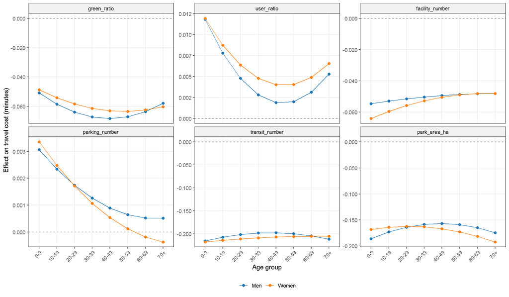

```r
me_long <- rbind(
  data.frame(me[, c("Amenity", "AgeGroup")], Sex = "Men",   ME = me$Men),
  data.frame(me[, c("Amenity", "AgeGroup")], Sex = "Women", ME = me$Women))

p_me <- ggplot(me_long, aes(AgeGroup, ME, colour = Sex, group = Sex)) +
  geom_hline(yintercept = 0, linetype = "dashed", colour = "grey50") +
  geom_line() + geom_point(size = 2) +
  facet_wrap(~ Amenity, scales = "free_y", ncol = 3) +
  scale_colour_manual(values = sex_cols) +
  scale_y_continuous(labels = fmt3) +
  labs(x = "Age group", y = "Effect on travel cost (minutes)") +
  theme_paper
p_me
```

```r
ggsave(file.path(out_dir, "marginal_effects_ccrem.png"), p_me,
       width = 12, height = 7, dpi = 300)
```

## Gender difference in marginal effects (Women − Men, 95% CI)

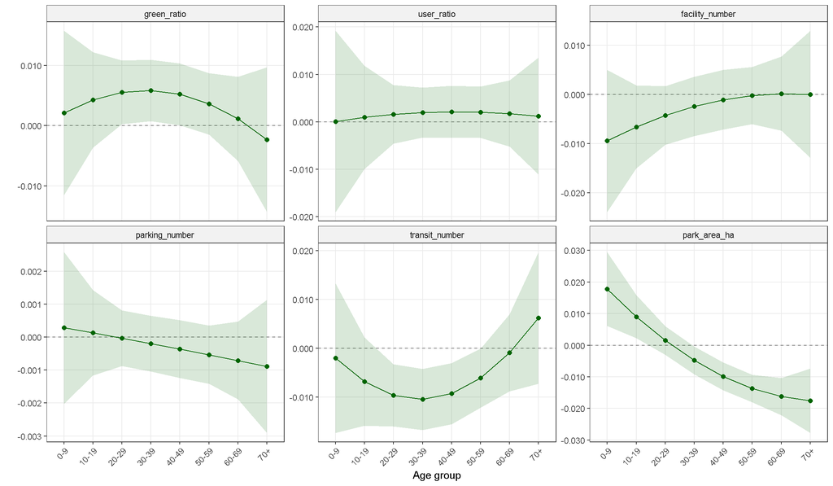

```r
me$lo <- me$Diff - 1.96 * me$Diff_se
me$hi <- me$Diff + 1.96 * me$Diff_se

p_gap <- ggplot(me, aes(AgeGroup, Diff, group = 1)) +
  geom_hline(yintercept = 0, linetype = "dashed", colour = "grey50") +
  geom_ribbon(aes(ymin = lo, ymax = hi), fill = "darkgreen", alpha = 0.15) +
  geom_line(colour = "darkgreen") + geom_point(colour = "darkgreen", size = 2) +
  facet_wrap(~ Amenity, scales = "free_y", ncol = 3) +
  scale_y_continuous(labels = fmt3) +
  labs(x = "Age group", y = "Women \u2212 Men (minutes)") +
  theme_paper
p_gap
```

```r
ggsave(file.path(out_dir, "marginal_effects_gap_ccrem.png"), p_gap,
       width = 12, height = 7, dpi = 300)
```

## Potential and realized accessibility by age group and sex

All values use the same 274-park sample as the regression. Ten-year values are visitor-weighted over all rows in the group.

```r
logsumexp <- function(x) { m <- max(x); m + log(sum(exp(x - m))) }

# Potential accessibility: logsum over parks for each origin gu
pairs <- dl[!duplicated(dl[, c("ID", "INFLOW_CD")]), c("ID", "INFLOW_CD", "c_eq_min")]
for (th in c(0.05, 0.10, 0.20)) {
  A_th <- tapply(pairs$c_eq_min, pairs$INFLOW_CD, function(x) logsumexp(-th * x))
  cat(sprintf("theta = %.2f: logsum range %.3f to %.3f\n", th, min(A_th), max(A_th)))
}
```

```
## theta = 0.05: logsum range 3.515 to 4.238
## theta = 0.10: logsum range 2.442 to 3.290
## theta = 0.20: logsum range 1.023 to 2.458
```

```r
A_origin <- tapply(pairs$c_eq_min, pairs$INFLOW_CD, function(x) logsumexp(-THETA * x))
dl$A_o <- A_origin[as.character(dl$INFLOW_CD)]

dl$Sex <- ifelse(dl$female == 1, "Women", "Men")
grp <- do.call(rbind, lapply(split(dl, list(dl$Sex, dl$age_label), drop = TRUE), function(x)
  data.frame(Sex = x$Sex[1], AgeGroup = x$age_label[1],
             A_weighted = weighted.mean(x$A_o, x$w),
             c_weighted = weighted.mean(x$c_eq_min, x$w))))
grp$AgeGroup <- factor(grp$AgeGroup, levels = LABEL_ORDER)
grp <- grp[order(grp$Sex, grp$AgeGroup), ]

gap <- data.frame(AgeGroup = factor(LABEL_ORDER, levels = LABEL_ORDER))
gap$A_gap <- grp$A_weighted[grp$Sex == "Women"] - grp$A_weighted[grp$Sex == "Men"]
gap$A_gap_minutes <- gap$A_gap / THETA
gap$c_gap <- grp$c_weighted[grp$Sex == "Women"] - grp$c_weighted[grp$Sex == "Men"]

write.csv(grp, file.path(out_dir, "group_accessibility.csv"), row.names = FALSE)
write.csv(gap, file.path(out_dir, "group_gaps.csv"), row.names = FALSE)
print(grp, digits = 5, row.names = FALSE)
```

```
##    Sex AgeGroup A_weighted c_weighted
##    Men      0-9     2.9901     30.775
##    Men    10-19     2.9995     31.147
##    Men    20-29     2.9910     32.217
##    Men    30-39     2.9819     32.866
##    Men    40-49     2.9854     33.047
##    Men    50-59     2.9850     32.861
##    Men    60-69     2.9836     32.062
##    Men      70+     2.9800     31.016
##  Women      0-9     2.9907     30.890
##  Women    10-19     2.9988     31.042
##  Women    20-29     2.9883     32.353
##  Women    30-39     2.9951     31.593
##  Women    40-49     3.0001     31.717
##  Women    50-59     2.9927     31.369
##  Women    60-69     2.9864     30.590
##  Women      70+     2.9820     30.382
```

```r
print(gap, digits = 4, row.names = FALSE)
```

```
##  AgeGroup      A_gap A_gap_minutes   c_gap
##       0-9  0.0005589      0.005589  0.1149
##     10-19 -0.0006451     -0.006451 -0.1054
##     20-29 -0.0027496     -0.027496  0.1352
##     30-39  0.0131522      0.131522 -1.2726
##     40-49  0.0146390      0.146390 -1.3304
##     50-59  0.0077409      0.077409 -1.4920
##     60-69  0.0028853      0.028853 -1.4714
##       70+  0.0019721      0.019721 -0.6335
```

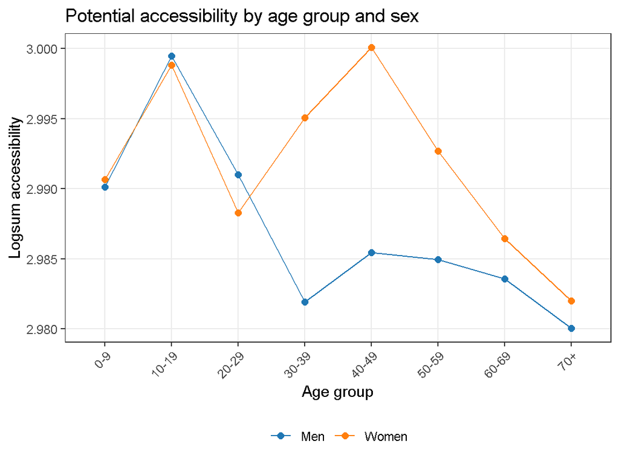

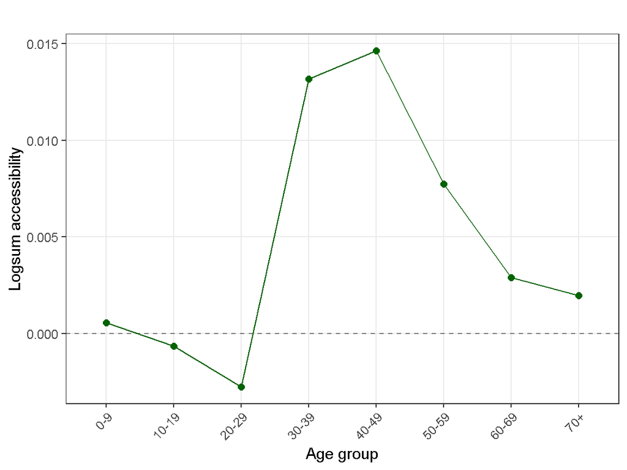

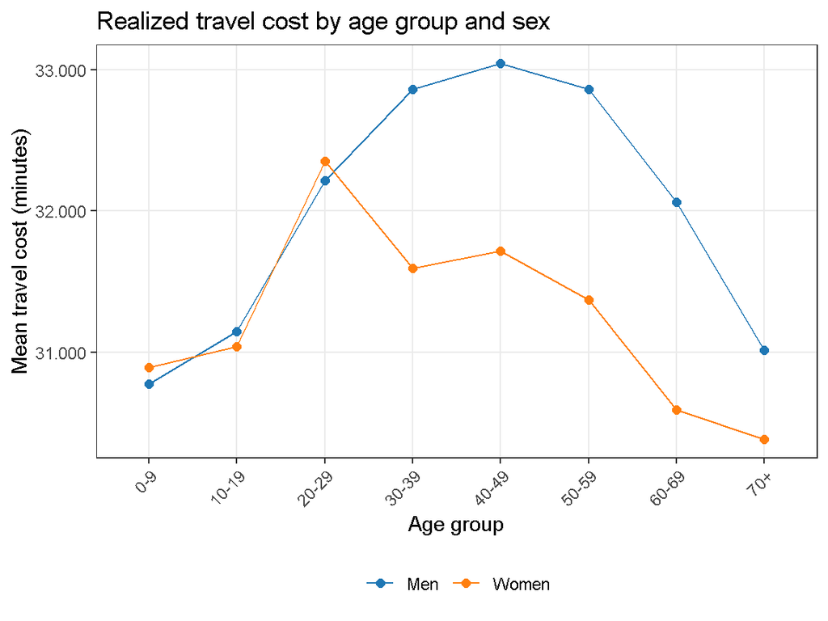

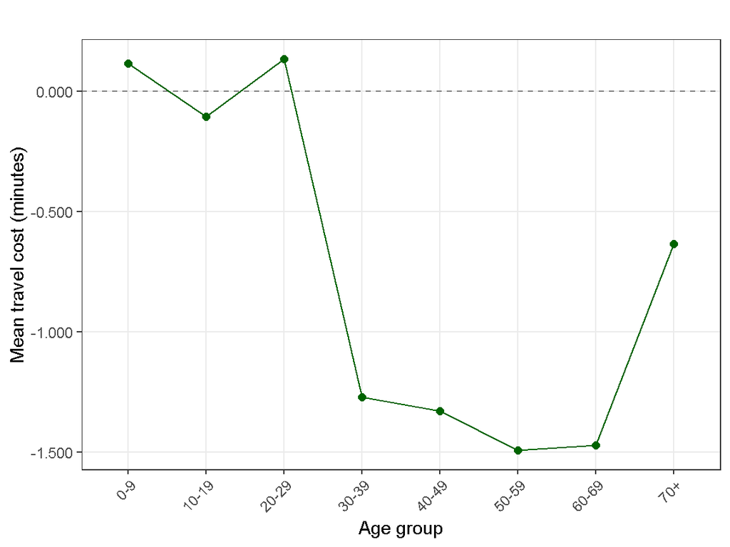

```r
line_fig <- function(y, ylab, title) {
  ggplot(grp, aes(AgeGroup, .data[[y]], colour = Sex, group = Sex)) +
    geom_line() + geom_point(size = 2) +
    scale_colour_manual(values = sex_cols) +
    scale_y_continuous(labels = fmt3) +
    labs(x = "Age group", y = ylab, title = title) + theme_paper
}
gap_fig <- function(y, ylab, title) {
  ggplot(gap, aes(AgeGroup, .data[[y]], group = 1)) +
    geom_hline(yintercept = 0, linetype = "dashed", colour = "grey50") +
    geom_line(colour = "darkgreen") + geom_point(colour = "darkgreen", size = 2) +
    scale_y_continuous(labels = fmt3) +
    labs(x = "Age group", y = ylab, title = title) + theme_paper
}

figs <- list(
  "logsum accessibility by sex and age.png" =
    line_fig("A_weighted", "Logsum accessibility", "Potential accessibility by age group and sex"),
  "gender difference in accessibility.png" =
    gap_fig("A_gap", "Logsum accessibility", "Gender difference in potential accessibility (Women \u2212 Men)"),
  "travel cost by sex and age.png" =
    line_fig("c_weighted", "Mean travel cost (minutes)", "Realized travel cost by age group and sex"),
  "gender difference in travel cost.png" =
    gap_fig("c_gap", "Mean travel cost (minutes)", "Gender difference in realized travel cost (Women \u2212 Men)"))

for (f in names(figs)) {
  print(figs[[f]])
  ggsave(file.path(out_dir, f), figs[[f]], width = 6, height = 4.5, dpi = 300)
}
```

# 9. Robustness check: origin fixed-effects model (Appendix A)

Same fixed-effect terms, 24 origin gu dummies instead of random intercepts, weighted least squares, standard errors clustered by park (CR1 correction).

```r
f_fe <- as.formula(paste("c_eq_min ~", paste(FIXED_TERMS, collapse = " + "),
                         "+ INFLOW_CD"))
fe <- lm(f_fe, data = dl, weights = w)

# Park-clustered standard errors, computed by hand (no extra package needed)
X  <- model.matrix(fe)
u  <- residuals(fe) * dl$w            # weighted residuals
XtWX_inv <- solve(crossprod(X, X * dl$w))
scores <- rowsum(X * u, group = dl$ID) # sum of x_i * w_i * e_i within each park
G <- nrow(scores); N <- nrow(X); K <- ncol(X)
meat <- crossprod(scores)
V_cl <- XtWX_inv %*% meat %*% XtWX_inv * (G / (G - 1)) * ((N - 1) / (N - K))

fe_tab <- data.frame(term = colnames(X), Estimate = coef(fe), SE = sqrt(diag(V_cl)))
fe_tab$p   <- 2 * pt(-abs(fe_tab$Estimate / fe_tab$SE), df = G - 1)
fe_tab$Sig <- stars(fe_tab$p)
fe_tab <- fe_tab[!grepl("^INFLOW_CD", fe_tab$term), ]
write.csv(fe_tab, file.path(out_dir, "fe_model_clustered.csv"), row.names = FALSE)
cat("R2:", round(summary(fe)$r.squared, 3), "\n")
```

```
## R2: 0.273
```

```r
print(fe_tab[, -1], digits = 4)
```

```
##                       Estimate        SE         p Sig
## (Intercept)          4.697e+01 4.679e+00 2.191e-20 ***
## female              -7.455e-01 8.724e-01 3.936e-01
## age_c                3.329e-02 3.343e-02 3.202e-01
## age_c_sq             1.809e-04 1.581e-03 9.090e-01
## female_age          -2.080e-02 2.061e-02 3.136e-01
## female_age2          2.563e-04 8.529e-04 7.640e-01
## green_ratio         -7.135e-02 4.599e-02 1.219e-01
## user_ratio          -1.835e-03 2.444e-02 9.402e-01
## facility_number     -5.244e-03 7.142e-02 9.415e-01
## parking_number      -3.628e-03 4.088e-03 3.756e-01
## transit_number      -2.410e-01 5.659e-02 2.825e-05 ***
## park_area_ha        -5.728e-02 4.333e-02 1.873e-01
## green_ratio_F        1.503e-02 1.119e-02 1.804e-01
## user_ratio_F         2.598e-03 7.165e-03 7.172e-01
## facility_number_F   -2.630e-02 1.408e-02 6.282e-02
## parking_number_F    -2.747e-04 1.233e-03 8.239e-01
## transit_number_F    -1.688e-02 1.069e-02 1.155e-01
## park_area_ha_F      -6.838e-03 6.677e-03 3.067e-01
## green_ratio_A       -6.149e-04 4.369e-04 1.604e-01
## user_ratio_A        -5.964e-04 6.324e-04 3.465e-01
## facility_number_A   -3.330e-04 2.788e-04 2.333e-01
## parking_number_A    -4.428e-05 3.147e-05 1.605e-01
## transit_number_A     8.784e-04 3.480e-04 1.217e-02   *
## park_area_ha_A      -6.796e-05 2.536e-04 7.889e-01
## green_ratio_A2       3.206e-06 1.881e-05 8.648e-01
## user_ratio_A2        2.127e-05 2.123e-05 3.171e-01
## facility_number_A2  -3.752e-05 1.966e-05 5.739e-02
## parking_number_A2    2.111e-06 1.752e-06 2.292e-01
## transit_number_A2   -2.106e-05 2.028e-05 3.000e-01
## park_area_ha_A2     -2.650e-05 1.307e-05 4.356e-02   *
## green_ratio_FA       1.978e-04 2.558e-04 4.400e-01
## user_ratio_FA        2.994e-04 2.995e-04 3.184e-01
## facility_number_FA  -7.626e-05 2.248e-04 7.347e-01
## parking_number_FA   -4.841e-06 3.464e-05 8.889e-01
## transit_number_FA   -1.768e-04 2.808e-04 5.296e-01
## park_area_ha_FA     -4.660e-04 1.947e-04 1.738e-02   *
## green_ratio_FA2     -9.758e-06 1.085e-05 3.692e-01
## user_ratio_FA2      -4.513e-06 7.021e-06 5.209e-01
## facility_number_FA2  2.072e-05 1.109e-05 6.293e-02
## parking_number_FA2   7.685e-08 1.077e-06 9.432e-01
## transit_number_FA2   1.690e-05 1.000e-05 9.224e-02
## park_area_ha_FA2     7.009e-06 6.189e-06 2.584e-01
```